# 🎓 Master of Science in Applied Data Science 🎓

## 🤖 Machine Learning and Predictive Analytics 🤖

## 📅 Week 4: Which Support Vectors Should You Recommend? 📅

## Instructions 📢

**Purpose:** This assignment aims to reinforce the concepts learned in Week 4, focusing on Support Vector Machines (SVM), Kernelized SVMs, and recommendation systems.

**Prerequisites:**

- Understanding of SVMs, Kernelized SVMs, and the concepts covered in previous weeks.

**How to Complete:**

- Follow the instructions provided for each question.
- Pay attention to the point values assigned to different parts.

**Additional Tips:**

- Collaboration is encouraged for discussions but submit your independent work.
- Experiment with different parameters and techniques to deepen your understanding.

## Question 1: SVM and Kernelized SVM Implementation (40 points)

### **Part A: Implementing SVM and Kernelized SVM (20 points)**

1. **Library Import:** Begin by importing the necessary libraries:

```python
import numpy as np
import pandas as pd
import matplotlib.pyplot as plt
from sklearn.svm import SVC
from sklearn.preprocessing import StandardScaler
from sklearn.model_selection import train_test_split
from sklearn.metrics import accuracy_score
```

2. **Dataset Loading:** Load the dataset labeled `Week_1_Train.csv` into a Pandas DataFrame.

```python
# Write your code here
df = pd.read_csv("/Users/edwinhsu/Assignment/Machine Learning & Predictive Analytics/Week_1_Train-3.csv")
df
```

|  | age | capital-gain | capital-loss | hours-per-week | education-num | class |
| --- | --- | --- | --- | --- | --- | --- |
| 0 | 18 | 0.0 | 0.0 | 12 | 8 | <=50K |
| 1 | 29 | 0.0 | 0.0 | 38 | 9 | <=50K |
| 2 | 29 | 0.0 | 0.0 | 52 | 10 | <=50K |
| 3 | 49 | 0.0 | 0.0 | 85 | 13 | >50K |
| 4 | 38 | 0.0 | 0.0 | 50 | 9 | >50K |
| ... | ... | ... | ... | ... | ... | ... |
| 39068 | 42 | 0.0 | 0.0 | 40 | 13 | <=50K |
| 39069 | 65 | 0.0 | 0.0 | 40 | 9 | <=50K |
| 39070 | 44 | 0.0 | 0.0 | 50 | 10 | >50K |
| 39071 | 35 | 0.0 | 0.0 | 40 | 13 | <=50K |
| 39072 | 47 | 15024.0 | 0.0 | 50 | 10 | >50K |

39073 rows × 6 columns

3. **Data Preprocessing:** Prepare the dataset for modeling. Assuming your data is in a DataFrame named 'df' with the target in column `class`, split into `X` and `y`:

```python
from sklearn.preprocessing import StandardScaler, LabelEncoder
# Separate the features and target variable
X = df.drop(columns=['class'])
y = df['class']

# Encode the target variable
label_encoder = LabelEncoder()
y_encoded = label_encoder.fit_transform(y)
X
```

|  | age | capital-gain | capital-loss | hours-per-week | education-num |
| --- | --- | --- | --- | --- | --- |
| 0 | 18 | 0.0 | 0.0 | 12 | 8 |
| 1 | 29 | 0.0 | 0.0 | 38 | 9 |
| 2 | 29 | 0.0 | 0.0 | 52 | 10 |
| 3 | 49 | 0.0 | 0.0 | 85 | 13 |
| 4 | 38 | 0.0 | 0.0 | 50 | 9 |
| ... | ... | ... | ... | ... | ... |
| 39068 | 42 | 0.0 | 0.0 | 40 | 13 |
| 39069 | 65 | 0.0 | 0.0 | 40 | 9 |
| 39070 | 44 | 0.0 | 0.0 | 50 | 10 |
| 39071 | 35 | 0.0 | 0.0 | 40 | 13 |
| 39072 | 47 | 15024.0 | 0.0 | 50 | 10 |

39073 rows × 5 columns

```python
y_encoded
```

```
array([0, 0, 0, ..., 1, 0, 1])
```

0 = <=50K  
1 = >50K

4. Apply `StandardScaler` to all features in `X`.

```python
# Apply StandardScaler to all features
scaler = StandardScaler()
X_scaled = scaler.fit_transform(X)
```

5. **Train/Test Split:** Split your data into `X_train`, `X_test`, `y_train`, and `y_test`

```python
# Train/Test Split
X_train, X_test, y_train, y_test = train_test_split(X_scaled, y_encoded, test_size=0.2, random_state=42)

X_train.shape, X_test.shape, y_train.shape, y_test.shape
```

```
((31258, 5), (7815, 5), (31258,), (7815,))
```

6. **SVM Implementation:** Implement a linear Support Vector Machine (SVM) model using scikit-learn using `X_train`, `y_train`, and `X_test`.
7. **Kernelized SVM Implementation:** Implement a Kernelized SVM model using scikit-learn with the Radial Basis Function (RBF) kernel using `X_train`, `y_train`, and `X_test`.

```python
from sklearn.svm import SVC

# Implementing a linear SVM
linear_svm = SVC(kernel='linear')
linear_svm.fit(X_train, y_train)
```

```
SVC(kernel='linear')
```

```python
# Implementing a Kernelized SVM with the RBF kernel
rbf_svm = SVC(kernel='rbf')
rbf_svm.fit(X_train, y_train)
```

```
SVC()
```

8. **Evaluation:** Calculate the accuracy of both SVM models on `y_test` and compare the results.

```python
# Scoring the model on the test set
linear_svm_score = linear_svm.score(X_test, y_test)
linear_svm_score
```

```
0.8015355086372361
```

```python
# Scoring the model on the test set
rbf_svm_score = rbf_svm.score(X_test, y_test)
rbf_svm_score
```

```
0.8261036468330134
```

- **Accuracy of the Linear SVM: Approximately 80.15%**
- **Accuracy of the Kernelized SVM with RBF Kernel: Approximately 82.61%**

These results were calculated earlier where the Kernelized SVM (RBF) showed better accuracy compared to the linear SVM. The higher accuracy of the RBF kernel model suggests it may be better at capturing the non-linear relationships in the dataset.

### **Part B: Build another Kernalized SVM (10 points)**

1. **Kernelized SVM Implementation:** Implement a Kernelized SVM model using scikit-learn with the `poly` or `sigmoid` kernel using `X_train`, `y_train`, and `X_test`.

```python
# Implementing a Kernelized SVM with the polynomial kernel
poly_svm = SVC(kernel='poly')
poly_svm.fit(X_train, y_train)
```

```
SVC(kernel='poly')
```

```python
# Implementing a Kernelized SVM with the sigmoid kernel
sigmoid_svm = SVC(kernel='sigmoid')
sigmoid_svm.fit(X_train, y_train)
```

```
SVC(kernel='sigmoid')
```

2. **Evaluation:** Calculate the accuracy of the Kernelized SVM model on `y_test` and compare the results.

```python
# Scoring the model on the test set
poly_svm_score = poly_svm.score(X_test, y_test)
poly_svm_score
```

```
0.8098528470889316
```

- **Linear SVM: 80.15%**
- **Kernelized SVM with RBF Kernel: 82.61%**
- **Kernelized SVM with Polynomial Kernel: 80.98%**

The RBF kernel still holds the best performance among these, while the polynomial kernel performs better than the linear SVM but not as well as the RBF kernel.

```python
# Scoring the model on the test set
sigmoid_svm_score = sigmoid_svm.score(X_test, y_test)
sigmoid_svm_score
```

```
0.7277031349968011
```

- **Linear SVM: 80.15%**
- **Kernelized SVM with RBF Kernel: 82.61%**
- **Kernelized SVM with Polynomial Kernel: 80.98%**
- **Kernelized SVM with Sigmoid Kernel: 72.77%**

The results indicate that the RBF kernel performs the best, followed by the polynomial and linear kernels, with the sigmoid kernel performing the least effectively. This suggests that the choice of kernel significantly impacts the model's ability to generalize, with the RBF kernel being particularly effective for this dataset.

### **Part C: Comparing SVM and KNN (10 points)**

1. **Comparison:** Compare the accuracy of the linear SVM, kernelized SVM (RBF), and the K-Nearest Neighbors (KNN) classifier from Week 1 based on accuracy.
2. **Explanation:** Provide an explanation of the observed differences in accuracy between the models.
3. **Conclusion:** Based on the comparison, discuss the strengths and weaknesses of each model in the context of the dataset used.

**Code Reuse:** Refer back to the pieces of Week 1 assignment code. You can copy and paste results from your KNNClassifier into this Week 4 notebook for comparing the SVM and KNN models.

```python
from sklearn.neighbors import KNeighborsClassifier
### Initialize and fit the KNN model
knn = KNeighborsClassifier(n_neighbors=5)  # Using 5 neighbors for KNN
```

```python
knn.fit(X_train, y_train)
```

```
KNeighborsClassifier()
```

```python
# Make predictions and evaluate the model
y_pred = knn.predict(X_test)
```

```python
accuracy = accuracy_score(y_test, y_pred)
accuracy
```

```
0.8042226487523992
```

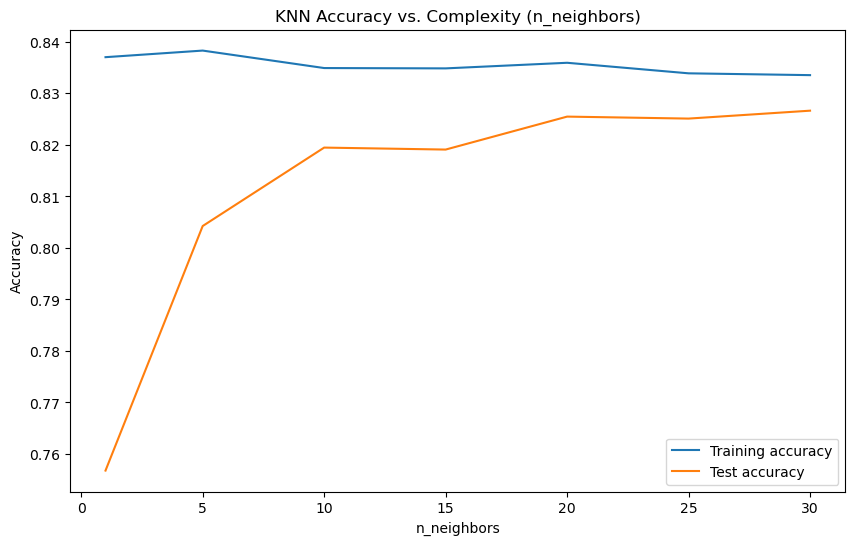

```
n_neighbors: 1, Training Acc: 0.8370, Test Acc: 0.7567
n_neighbors: 5, Training Acc: 0.8383, Test Acc: 0.8042
n_neighbors: 10, Training Acc: 0.8349, Test Acc: 0.8194
n_neighbors: 15, Training Acc: 0.8348, Test Acc: 0.8191
n_neighbors: 20, Training Acc: 0.8359, Test Acc: 0.8255
n_neighbors: 25, Training Acc: 0.8339, Test Acc: 0.8251
n_neighbors: 30, Training Acc: 0.8335, Test Acc: 0.8266
```

```python
# Values of n_neighbors to experiment with
neighbors_settings = [1, 5, 10, 15, 20, 25, 30]

# Lists to store the accuracies
training_accuracy = []
test_accuracy = []

# Loop over different values of n_neighbors
for n_neighbors in neighbors_settings:
    # Build the model
    clf = KNeighborsClassifier(n_neighbors=n_neighbors)
    clf.fit(X_train, y_train)

    # Record training set accuracy
    training_accuracy.append(clf.score(X_train, y_train))
    # Record test set accuracy
    test_accuracy.append(clf.score(X_test, y_test))

# Plotting the results
plt.figure(figsize=(10, 6))
plt.plot(neighbors_settings, training_accuracy, label="Training accuracy")
plt.plot(neighbors_settings, test_accuracy, label="Test accuracy")
plt.ylabel("Accuracy")
plt.xlabel("n_neighbors")
plt.legend()
plt.title("KNN Accuracy vs. Complexity (n_neighbors)")
plt.show()

# Print the accuracies for each n_neighbors
for n, train_acc, test_acc in zip(neighbors_settings, training_accuracy, test_accuracy):
    print(f"n_neighbors: {n}, Training Acc: {train_acc:.4f}, Test Acc: {test_acc:.4f}")
```

# ✍️ Respond to the question in this markdown cell ✍️

- **Linear SVM: 80.15%**
- **Kernelized SVM with RBF Kernel: 82.61%**
- **Kernelized SVM with Polynomial Kernel: 80.98%**
- **Kernelized SVM with Sigmoid Kernel: 72.77%**
- **KNN (n_neighbors=20): 82.55%**

### Explanation of Observed Differences in Accuracy

**SVM Models:** The differences in accuracy among the SVM models can be attributed to how each kernel handles the data's geometric distribution. The RBF kernel, which can manage complex, non-linear boundaries, performs best, suggesting non-linear relationships in the dataset. The polynomial kernel, offering a compromise between linear and complex non-linear mappings, outperforms the linear model but is less effective than RBF. The sigmoid kernel generally performs worse in many classification problems, as seen here, likely due to its output characteristics which are less suited for clear margin separation in SVM.

**KNN:** KNN performed comparably to the best SVM model, which suggests that proximity-based classification is very effective for this dataset. The high accuracy also indicates that local similarity is a strong indicator in this dataset, and that the features form well-clustered groups. The choice of 20 neighbors may have provided a good balance between bias and variance, enhancing its performance.

### Conclusion

**Strengths:**

- **SVM with RBF Kernel:** Best for capturing non-linear patterns, thus providing high accuracy where relationships between feature variables are complex.
- **Polynomial Kernel SVM:** Useful when the data contains interactions of features at multiple scales (due to terms of different degrees).
- **Linear SVM:** Efficient and straightforward, best when data is linearly separable or nearly so.
- **KNN:** Strong performance without assumptions about data distribution; excels when data naturally clusters well.

**Weaknesses:** SVM with Sigmoid Kernel: Generally lower performance can reflect issues with how the kernel maps the decision boundary in higher-dimensional space. Linear and Polynomial Kernel SVM: May underperform if the true decision boundary is highly non-linear or complex beyond the polynomial degree set. KNN: Computationally intensive as the dataset grows; performance highly dependent on the choice of the number of neighbors and the distance metric.

## Question 2: Building Recommendation Systems (60 points)

### **Part A: Package Install, Data Loading, and EDA (15 Points)**

1. **Install:** You will be using a `python` package for developing recommender systems named `surprise`. Here is a [link](https://surpriselib.com/) to the home page for `surprise` that will help guide you to the relevant `documentation` for completing this exercise.

```python
pip install surprise
```

```
  Obtaining dependency information for surprise from https://files.pythonhosted.org/packages/61/de/e5cba8682201fcf9c3719a6fdda95693468ed061945493dea2dd37c5618b/surprise-0.1-py2.py3-none-any.whl.metadata
     ━━━━━━━━━━━━━━━━━━━━━━━━━━━━━━━━━━━━━━━ 772.0/772.0 kB 1.6 MB/s eta 0:00:00a 0:00:01
  Preparing metadata (setup.py) ... done
Downloading surprise-0.1-py2.py3-none-any.whl (1.8 kB)
```

2. **Load the necessary packages:** The assignment will require you to load additional algorithms so it is highly recommended you open the `surprise` documentation to assist with completing the assignment successfully. Here are the libraries you will need to begin.

```python
import pandas as pd
from surprise import Dataset, Reader
from surprise.model_selection import train_test_split, cross_validate
from surprise import NormalPredictor, BaselineOnly, KNNBaseline
from surprise import accuracy
```

3. **Load Your Dataset:** Load the dataset labeled `Week_4_Train.csv` into a Pandas DataFrame. Replace the placeholders with the correct file path and format based on how the data is stored (CSV, Excel, etc.) 💾
- This dataset contains three columns.
  - `user_id` which is the unique user id
  - `item_id` which is the unique movie id
  - `rating` which is the user rating for a given movie

```python
# Write your code here.
df = pd.read_csv('/Users/edwinhsu/Assignment/Machine Learning & Predictive Analytics/Week_4_Train.csv')
df
```

|  | user_id | item_id | rating |
| --- | --- | --- | --- |
| 0 | 1 | 1 | 5 |
| 1 | 1 | 2 | 3 |
| 2 | 1 | 3 | 4 |
| 3 | 1 | 4 | 3 |
| 4 | 1 | 5 | 3 |
| ... | ... | ... | ... |
| 79995 | 943 | 1067 | 2 |
| 79996 | 943 | 1074 | 4 |
| 79997 | 943 | 1188 | 3 |
| 79998 | 943 | 1228 | 3 |
| 79999 | 943 | 1330 | 3 |

80000 rows × 3 columns

4. Calculate the total number of `rating`, `item_id`, and `user_id` in the dataset to begin to get a sense of the nature of the underlying datset.

```python
# Calculate the total number of unique entries in each column
unique_users = df['user_id'].nunique()
unique_items = df['item_id'].nunique()
unique_ratings = df['rating'].nunique()

unique_users, unique_items, unique_ratings
```

```
(943, 1650, 5)
```

5. Calculate the the average number of `ratings` per `item_id` and the average number of ratings per `user_id` from the data.

```python
# Calculate the average number of ratings per item_id and per user_id
avg_ratings_per_item = df.groupby('item_id').size().mean()
avg_ratings_per_user = df.groupby('user_id').size().mean()

avg_ratings_per_item, avg_ratings_per_user
```

```
(48.484848484848484, 84.83563096500531)
```

6. Calculate how many unique `item_id` and `user_id` have fewer than 10 ratings?

```python
# Calculate the number of ratings per item_id and per user_id
ratings_per_item = df.groupby('item_id').size()
ratings_per_user = df.groupby('user_id').size()

# Find the number of items and users with fewer than 10 ratings
items_fewer_than_10 = (ratings_per_item < 10).sum()
users_fewer_than_10 = (ratings_per_user < 10).sum()

items_fewer_than_10, users_fewer_than_10
```

```
(573, 6)
```

7. Determine the `rating` scale (e.g., 1 - 10) from the data.

```python
# Find the minimum and maximum rating values
rating_scale_min = df['rating'].min()
rating_scale_max = df['rating'].max()

rating_scale_min, rating_scale_max
```

```
(1, 5)
```

8. Create a barplot of the distribution of ratings for the data.

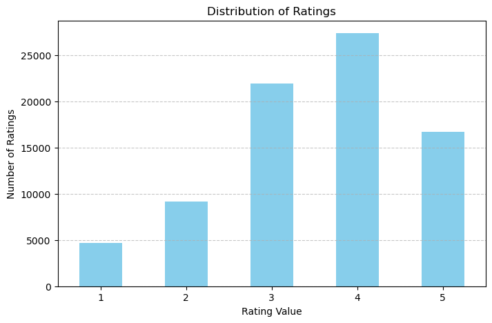

```python
import matplotlib.pyplot as plt

# Count the occurrences of each rating
rating_counts = df['rating'].value_counts().sort_index()

# Create a bar plot
plt.figure(figsize=(8, 5))
rating_counts.plot(kind='bar', color='skyblue')
plt.title('Distribution of Ratings')
plt.xlabel('Rating Value')
plt.ylabel('Number of Ratings')
plt.xticks(rotation=0)
plt.grid(axis='y', linestyle='--', alpha=0.7)
plt.show()
```

### **Part B: Pre-process data for building recommender (15 Points)**

1. Filter out all movies that have been rated fewer than 10 times and all users who have rated fewer than 10 movies.

```python
# Filter items and users with fewer than 10 ratings
items_with_at_least_10 = ratings_per_item[ratings_per_item >= 10].index
users_with_at_least_10 = ratings_per_user[ratings_per_user >= 10].index

# Filter the original dataset
filtered_data = df[df['item_id'].isin(items_with_at_least_10) & df['user_id'].isin(users_with_at_least_10)]

# Check the size of the filtered dataset
filtered_data.shape
```

```
(77722, 3)
```

```python
df.shape
```

```
(80000, 3)
```

2. Prepare the `Reader` object to convert `pandas.DataFrame` into a `Surprise.dataset`. To do this you need to take advantage of some of the EDA work by using the ratings scale you determined above.
- Hint - replace `Min` and `Max` in the code below with the actual numeric values of the `rating` scale. Here is a [link](https://surprise.readthedocs.io/en/stable/reader.html?highlight=Reader#reader-class) to the `Reader` documentation in `Surprise`

```python
# Write your code here.
#reader = Reader(rating_scale=(MIN, MAX))

reader = Reader(rating_scale=(1, 5))  # Replace Min and Max with 1 and 5 respectively
```

3. Convert `pandas.Dataframe` to `Surprise` object using `reader` which you just created and your `df`. Name the new object `data`.
- Hint - Use the `Dataset.load_from_df()`, here is a [link](https://surprise.readthedocs.io/en/stable/dataset.html?highlight=.load_from_df#surprise.dataset.Dataset.load_from_df) to this in the `Surprise` documention. Replace `OBJECT1` and `OBJECT2` with the appropriate objects.

```python
# Write your code here.
#data = Dataset.load_from_df(OBJECT1, OBJECT2)
data = Dataset.load_from_df(filtered_data[['user_id', 'item_id', 'rating']], reader)
```

4. Examine the Suprise Object. This will be quite different than what you are accustom to seeing from a `pandas.DataFrame`

```python
# Build the full trainset
trainset = data.build_full_trainset()
# Explore the trainset
print("Number of users:", trainset.n_users)
print("Number of items:", trainset.n_items)
print("Number of ratings:", trainset.n_ratings)
```

```
Number of users: 937
Number of items: 1077
Number of ratings: 77722
```

```python
# To see the first few entries in the dataset
for (uid, iid, rating) in trainset.all_ratings():
    print("User ID:", uid, "Item ID:", iid, "Rating:", rating)
    break  # Remove or modify this break statement to see more or fewer entries
```

```
User ID: 0 Item ID: 0 Rating: 5.0
```

### **Part C: Build baseline recommenders (10 Points)**

1. I have written a flexible recommender evaluation function for you to utilize for this assignment.
- Prior to running the function below, evaluate it reading the docstring so you know how it works.
- Understanding the function is crucial for completing the assignment as you will have to leverage this in Part D!
- Execute the cell when you have a firm understanding of the function.

```python
def evaluate_algorithms(data, algorithms, cv=3, verbose=True):
    """Evaluates a list of collaborative-filtering algorithms on a dataset using cross-validation.

    Args:
        data (pandas.DataFrame): The dataset to use for evaluation.
        algorithms (list): A list of collaborative-filtering algorithm objects to evaluate.
        cv (int, optional): The number of cross-validation folds to use. Defaults to 3.
        verbose (bool, optional): Controls verbosity of the cross-validation process. Defaults to True.
    Returns:
        pandas.DataFrame: A DataFrame containing evaluation results and rankings
                          for each algorithm by Root Mean Squared Error (RMSE), Mean
                          Squared Error (MSE), Mean Absolute Error (MAE), Fraction
                          of Concordant Pairs (FCP).
    """

    benchmark = []
    # Iterate over algorithms
    for algorithm in algorithms:
        # Perform cross validation
        results = cross_validate(algorithm, data, measures=['RMSE', 'MAE', 'MSE', 'FCP'], cv=cv, verbose=verbose)

        # Get results & append algorithm name
        results_df = pd.DataFrame.from_dict(results).mean(axis=0)
        new_series = pd.Series([str(algorithm).split(' ')[0].split('.')[-1]], index=['Algorithm'])
        results_df = pd.concat([results_df, new_series], axis=0)
        benchmark.append(results_df)

    # Create benchmark DataFrame
    benchmark_df = pd.DataFrame(benchmark).set_index('Algorithm').sort_values('test_rmse')

    # Add ranking columns
    benchmark_df['RMSE Rank'] = benchmark_df['test_rmse'].rank(ascending=True).astype(int)
    benchmark_df['MAE Rank'] = benchmark_df['test_mae'].rank(ascending=True).astype(int)
    benchmark_df['MSE Rank'] = benchmark_df['test_mse'].rank(ascending=True).astype(int)
    benchmark_df['FCP Rank'] = benchmark_df['test_fcp'].rank(ascending=False).astype(int)

    return benchmark_df.round(4)
```

2. Below is an example of you how use the function.
- Note that in this example I have selected three algorithms.
- Execute the example.

```python
# Example Usage

# Function Parameters
data = data
algorithms_to_test = [NormalPredictor(), BaselineOnly(), KNNBaseline()]
cv = 3

# Execute the Function and Print the Results
results = evaluate_algorithms(data, algorithms_to_test, cv)
results
```

```
Evaluating RMSE, MAE, MSE, FCP of algorithm NormalPredictor on 3 split(s).

                  Fold 1  Fold 2  Fold 3  Mean    Std
RMSE (testset)    1.5076  1.4863  1.4908  1.4949  0.0092
MAE (testset)     1.2124  1.1931  1.1982  1.2013  0.0082
MSE (testset)     2.2727  2.2090  2.2225  2.2347  0.0274
FCP (testset)     0.4918  0.4990  0.4955  0.4954  0.0029
Fit time          0.03    0.02    0.03    0.03    0.00
Test time         0.05    0.10    0.04    0.06    0.03
Estimating biases using als...
Estimating biases using als...
Estimating biases using als...
Evaluating RMSE, MAE, MSE, FCP of algorithm BaselineOnly on 3 split(s).

                  Fold 1  Fold 2  Fold 3  Mean    Std
RMSE (testset)    0.9422  0.9414  0.9476  0.9437  0.0027
MAE (testset)     0.7494  0.7477  0.7520  0.7497  0.0018
MSE (testset)     0.8877  0.8863  0.8979  0.8906  0.0052
FCP (testset)     0.6954  0.6989  0.6917  0.6954  0.0029
Fit time          0.02    0.03    0.03    0.03    0.00
Test time         0.10    0.03    0.10    0.08    0.03
Estimating biases using als...
Computing the msd similarity matrix...
Done computing similarity matrix.
Estimating biases using als...
Computing the msd similarity matrix...
Done computing similarity matrix.
Estimating biases using als...
Computing the msd similarity matrix...
Done computing similarity matrix.
Evaluating RMSE, MAE, MSE, FCP of algorithm KNNBaseline on 3 split(s).

                  Fold 1  Fold 2  Fold 3  Mean    Std
RMSE (testset)    0.9324  0.9400  0.9313  0.9346  0.0038
MAE (testset)     0.7382  0.7396  0.7381  0.7386  0.0007
MSE (testset)     0.8694  0.8835  0.8673  0.8734  0.0072
FCP (testset)     0.7009  0.7008  0.7016  0.7011  0.0004
Fit time          0.07    0.07    0.07    0.07    0.00
Test time         1.36    1.41    1.34    1.37    0.03
```

| Algorithm | test_rmse | test_mae | test_mse | test_fcp | fit_time | test_time | RMSE Rank | MAE Rank | MSE Rank | FCP Rank |
| --- | --- | --- | --- | --- | --- | --- | --- | --- | --- | --- |
| KNNBaseline | 0.9346 | 0.7386 | 0.8734 | 0.7011 | 0.0663 | 1.3729 | 1 | 1 | 1 | 1 |
| BaselineOnly | 0.9437 | 0.7497 | 0.8906 | 0.6954 | 0.0252 | 0.0773 | 2 | 2 | 2 | 2 |
| NormalPredictor | 1.4949 | 1.2013 | 2.2347 | 0.4954 | 0.0267 | 0.0612 | 3 | 3 | 3 | 3 |

3. In this simple example `KNNBaseline` gave us the best RMSE, MAE, MSE, and FCP therefore we will train and predict with `KNNBaseline`.
- We first will create a similarity dictionary, see [link](https://surprise.readthedocs.io/en/stable/prediction_algorithms.html#similarity-measures-configuration) for more details on Similarity measure configurations. and baseline estimates.
- Next we will create a baseline dictionary, see [link](https://surprise.readthedocs.io/en/stable/prediction_algorithms.html#baselines-estimates-configuration) for more details on Baseline estimate configurations.
- Execute cell

```python
# Example Usage
sim_options = {
    "name": "cosine",
    "user_based": False,
}

bsl_options = {
    "method": "als",
    "n_epochs": 20,
}
```

4. Now execute our `KNNBaseline` using `cross_validate` and can evaluate performance across folds.

```python
# Example Usage
algo = KNNBaseline(bsl_options=bsl_options, sim_options=sim_options)
cross_validate(algo, data, measures=['RMSE', 'MAE', 'MSE', 'FCP'], cv=3, verbose=True)
```

```
Estimating biases using als...
Computing the cosine similarity matrix...
Done computing similarity matrix.
Estimating biases using als...
Computing the cosine similarity matrix...
Done computing similarity matrix.
Estimating biases using als...
Computing the cosine similarity matrix...
Done computing similarity matrix.
Evaluating RMSE, MAE, MSE, FCP of algorithm KNNBaseline on 3 split(s).

                  Fold 1  Fold 2  Fold 3  Mean    Std
RMSE (testset)    0.9454  0.9472  0.9384  0.9437  0.0038
MAE (testset)     0.7496  0.7468  0.7395  0.7453  0.0043
MSE (testset)     0.8939  0.8972  0.8805  0.8905  0.0072
FCP (testset)     0.6921  0.6904  0.6926  0.6917  0.0010
Fit time          0.13    0.12    0.11    0.12    0.01
Test time         1.50    1.42    1.49    1.47    0.03
```

```
{'test_rmse': array([0.94544541, 0.94722888, 0.93836906]),
 'test_mae': array([0.74964268, 0.74675299, 0.73948435]),
 'test_mse': array([0.89386702, 0.89724256, 0.88053649]),
 'test_fcp': array([0.69213972, 0.69035197, 0.69262233]),
 'fit_time': (0.13094186782836914, 0.11618471145629883, 0.11416769027709961),
 'test_time': (1.4973318576812744, 1.4247331619262695, 1.4926090240478516)}
```

5. Next we split our data into train and test sets to make predictions.

```python
# Example Usage
trainset, testset = train_test_split(data, test_size=0.25)
```

6. Now let's leverage the model to make a set of predictions for ratings using our `trainset` and `testset`.

```python
# Example Usage
algo = KNNBaseline(bsl_options=bsl_options, sim_options=sim_options)
predictions = algo.fit(trainset).test(testset)
accuracy.rmse(predictions)
```

```
Estimating biases using als...
Computing the cosine similarity matrix...
Done computing similarity matrix.
RMSE: 0.9386
```

```
0.9385945758384483
```

7. To ease the interpretation I have written another helper function for you that will pull together the predictions into a nice tabular form.
- Familiarize yourself with the paramters and what is returned from this function as it will enable you to further explore the rating predictions.
- When you are ready run the cell.

```python
def analyze_predictions(predictions, trainset):
    """Analyzes predictions from the Surprise package, adding helpful columns.

    Args:
        predictions (list): A list of prediction objects as returned by
                            Surprise algorithms.
        trainset (Surprise.Dataset): The training dataset used to fit the model.

    Returns:
        pandas.DataFrame: A DataFrame with the following columns:

            * uid: User ID.
            * iid: Item ID.
            * actual: Real/true rating
            * predicted: Estimated rating.
            * details: JSON-string with prediction details:
                * actual_k: Number of neighbors used (if applicable).
                * was_impossible: Whether a prediction was possible.
            * Iu: Number of items the user has rated.
            * Ui: Number of users who rated the item.
            * error: Absolute error between the true and estimated rating.
    """

    # Create initial DataFrame
    df = pd.DataFrame(predictions, columns=['uid', 'iid', 'actual', 'predicted', 'details'])

    # Calculate Iu (number of items rated by the user)
    def get_Iu(uid):
        try:
            return len(trainset.ur[trainset.to_inner_uid(uid)])
        except ValueError:
            return 0

    df['Iu'] = df.uid.apply(get_Iu)

    # Calculate Ui (number of users who rated the item)
    def get_Ui(iid):
        try:
            return len(trainset.ir[trainset.to_inner_iid(iid)])
        except ValueError:
            return 0

    df['Ui'] = df.iid.apply(get_Ui)

    # Calculate error
    df['error'] = abs(df.predicted - df.actual)

    return df
```

8. Now let's use the function and take a look at the resulting table.

```python
# Example Usage
result_df = analyze_predictions(predictions, trainset)
result_df
```

|  | uid | iid | actual | predicted | details | Iu | Ui | error |
| --- | --- | --- | --- | --- | --- | --- | --- | --- |
| 0 | 239 | 528 | 5.0 | 4.349293 | {'actual_k': 40, 'was_impossible': False} | 67 | 73 | 0.650707 |
| 1 | 708 | 127 | 3.0 | 4.198852 | {'actual_k': 40, 'was_impossible': False} | 86 | 263 | 1.198852 |
| 2 | 543 | 129 | 4.0 | 3.688890 | {'actual_k': 40, 'was_impossible': False} | 136 | 82 | 0.311110 |
| 3 | 535 | 507 | 5.0 | 3.979439 | {'actual_k': 40, 'was_impossible': False} | 162 | 62 | 1.020561 |
| 4 | 893 | 815 | 3.0 | 3.514853 | {'actual_k': 40, 'was_impossible': False} | 42 | 57 | 0.514853 |
| ... | ... | ... | ... | ... | ... | ... | ... | ... |
| 19426 | 916 | 241 | 4.0 | 3.545201 | {'actual_k': 40, 'was_impossible': False} | 246 | 70 | 0.454799 |
| 19427 | 880 | 27 | 3.0 | 3.207162 | {'actual_k': 40, 'was_impossible': False} | 263 | 27 | 0.207162 |
| 19428 | 524 | 42 | 3.0 | 3.668542 | {'actual_k': 40, 'was_impossible': False} | 211 | 83 | 0.668542 |
| 19429 | 474 | 286 | 5.0 | 3.830128 | {'actual_k': 40, 'was_impossible': False} | 243 | 283 | 1.169872 |
| 19430 | 42 | 50 | 5.0 | 4.436299 | {'actual_k': 40, 'was_impossible': False} | 66 | 363 | 0.563701 |

19431 rows × 8 columns

### **Part D: Build 3 new recommenders (10 Points)**

1. Import the necessary algorithms for building three new recommenders from `Surprise`.

```python
from surprise import SVD
from surprise import SVDpp
from surprise import NMF
```

2. Leverage the `evaluate_algorithms` function to test different approaches.
- **Hint** Return to Part C, Question 2 for implementation guidance.

```python
# Function Parameters
data = data
algorithms_to_test = [SVD(), SVDpp(), NMF(), KNNBaseline()]
cv = 3

# Execute the Function and Print the Results
results = evaluate_algorithms(data, algorithms_to_test, cv)
results
```

```
Evaluating RMSE, MAE, MSE, FCP of algorithm SVD on 3 split(s).

                  Fold 1  Fold 2  Fold 3  Mean    Std
RMSE (testset)    0.9493  0.9479  0.9433  0.9468  0.0026
MAE (testset)     0.7485  0.7483  0.7468  0.7479  0.0007
MSE (testset)     0.9011  0.8985  0.8898  0.8965  0.0048
FCP (testset)     0.6822  0.6926  0.6928  0.6892  0.0049
Fit time          0.29    0.29    0.29    0.29    0.00
Test time         0.06    0.06    0.15    0.09    0.04
Evaluating RMSE, MAE, MSE, FCP of algorithm SVDpp on 3 split(s).

                  Fold 1  Fold 2  Fold 3  Mean    Std
RMSE (testset)    0.9319  0.9273  0.9309  0.9300  0.0020
MAE (testset)     0.7323  0.7283  0.7342  0.7316  0.0025
MSE (testset)     0.8684  0.8599  0.8666  0.8650  0.0037
FCP (testset)     0.6989  0.7043  0.7002  0.7011  0.0023
Fit time          3.13    3.05    3.05    3.08    0.04
Test time         1.44    1.41    1.39    1.41    0.02
Evaluating RMSE, MAE, MSE, FCP of algorithm NMF on 3 split(s).

                  Fold 1  Fold 2  Fold 3  Mean    Std
RMSE (testset)    0.9820  0.9774  0.9714  0.9769  0.0043
MAE (testset)     0.7713  0.7686  0.7660  0.7686  0.0021
MSE (testset)     0.9643  0.9554  0.9436  0.9544  0.0084
FCP (testset)     0.6802  0.6805  0.6802  0.6803  0.0001
Fit time          0.33    0.34    0.39    0.35    0.03
Test time         0.05    0.13    0.06    0.08    0.04
Estimating biases using als...
Computing the msd similarity matrix...
Done computing similarity matrix.
Estimating biases using als...
Computing the msd similarity matrix...
Done computing similarity matrix.
Estimating biases using als...
Computing the msd similarity matrix...
Done computing similarity matrix.
Evaluating RMSE, MAE, MSE, FCP of algorithm KNNBaseline on 3 split(s).

                  Fold 1  Fold 2  Fold 3  Mean    Std
RMSE (testset)    0.9349  0.9325  0.9365  0.9346  0.0016
MAE (testset)     0.7392  0.7396  0.7374  0.7387  0.0010
MSE (testset)     0.8739  0.8696  0.8771  0.8736  0.0031
FCP (testset)     0.7062  0.7008  0.6992  0.7021  0.0030
Fit time          0.06    0.07    0.07    0.07    0.00
Test time         1.36    1.43    1.37    1.39    0.03
```

| Algorithm | test_rmse | test_mae | test_mse | test_fcp | fit_time | test_time | RMSE Rank | MAE Rank | MSE Rank | FCP Rank |
| --- | --- | --- | --- | --- | --- | --- | --- | --- | --- | --- |
| SVDpp | 0.9300 | 0.7316 | 0.8650 | 0.7011 | 3.0801 | 1.4128 | 1 | 1 | 1 | 2 |
| KNNBaseline | 0.9346 | 0.7387 | 0.8736 | 0.7021 | 0.0653 | 1.3893 | 2 | 2 | 2 | 1 |
| SVD | 0.9468 | 0.7479 | 0.8965 | 0.6892 | 0.2912 | 0.0899 | 3 | 3 | 3 | 3 |
| NMF | 0.9769 | 0.7686 | 0.9544 | 0.6803 | 0.3491 | 0.0799 | 4 | 4 | 4 | 4 |

2. Split `data` into train and test sets to make predictions.

```python
trainset, testset = train_test_split(data, test_size=0.25)
```

3. Create a similarity dictionary and baseline estimate dictionary for your top model.

❗️Because SVDpp doesn't use the same concept of similarity matrices or baselines as neighborhood models do. Instead, it extends SVD by taking into account implicit ratings. Hence we would leave the similarity dictionary and baseline estimate dictionary empty for SVDpp model

4. Now leverage the top performing model to make a set of predictions for ratings using our `trainset` and `testset`.

```python
algo = SVDpp()
predictions = algo.fit(trainset).test(testset)
accuracy.rmse(predictions)
```

```
RMSE: 0.9232
```

```
0.923159639046341
```

5. Now use the `analyze_predictions` function and take a look at the resulting table.

```python
result_df = analyze_predictions(predictions, trainset)
result_df
```

|  | uid | iid | actual | predicted | details | Iu | Ui | error |
| --- | --- | --- | --- | --- | --- | --- | --- | --- |
| 0 | 267 | 164 | 3.0 | 3.772379 | {'was_impossible': False} | 86 | 90 | 0.772379 |
| 1 | 75 | 685 | 4.0 | 3.063316 | {'was_impossible': False} | 38 | 95 | 0.936684 |
| 2 | 545 | 1 | 5.0 | 4.064798 | {'was_impossible': False} | 114 | 286 | 0.935202 |
| 3 | 882 | 932 | 4.0 | 3.095704 | {'was_impossible': False} | 91 | 24 | 0.904296 |
| 4 | 526 | 342 | 2.0 | 2.377049 | {'was_impossible': False} | 51 | 33 | 0.377049 |
| ... | ... | ... | ... | ... | ... | ... | ... | ... |
| 19426 | 886 | 100 | 4.0 | 3.341044 | {'was_impossible': False} | 175 | 289 | 0.658956 |
| 19427 | 804 | 91 | 4.0 | 3.489674 | {'was_impossible': False} | 258 | 88 | 0.510326 |
| 19428 | 606 | 148 | 3.0 | 3.727342 | {'was_impossible': False} | 168 | 69 | 0.727342 |
| 19429 | 472 | 831 | 5.0 | 3.599724 | {'was_impossible': False} | 188 | 49 | 1.400276 |
| 19430 | 536 | 480 | 5.0 | 4.567560 | {'was_impossible': False} | 118 | 101 | 0.432440 |

19431 rows × 8 columns

### **Part E: Analyze Your Collaborative Filtering Model Results (10 Points)**

```python
# Write your code here.
titles = pd.read_csv('/Users/edwinhsu/Assignment/Machine Learning & Predictive Analytics/Week_4_titles.csv')
titles
```

|  | iid | title |
| --- | --- | --- |
| 0 | 1 | Toy Story (1995) |
| 1 | 2 | GoldenEye (1995) |
| 2 | 3 | Four Rooms (1995) |
| 3 | 4 | Get Shorty (1995) |
| 4 | 5 | Copycat (1995) |
| ... | ... | ... |
| 1677 | 1678 | Mat' i syn (1997) |
| 1678 | 1679 | B. Monkey (1998) |
| 1679 | 1680 | Sliding Doors (1998) |
| 1680 | 1681 | You So Crazy (1994) |
| 1681 | 1682 | Scream of Stone (Schrei aus Stein) (1991) |

1682 rows × 2 columns

2. Merge the results dataframe with the titles dataframe.

```python
# Now, perform the merge operation
merged_df = pd.merge(result_df, titles, on='iid', how='left')

# Display the head of the merged dataframe to check
merged_df
```

|  | uid | iid | actual | predicted | details | Iu | Ui | error | title |
| --- | --- | --- | --- | --- | --- | --- | --- | --- | --- |
| 0 | 267 | 164 | 3.0 | 3.772379 | {'was_impossible': False} | 86 | 90 | 0.772379 | Abyss, The (1989) |
| 1 | 75 | 685 | 4.0 | 3.063316 | {'was_impossible': False} | 38 | 95 | 0.936684 | Executive Decision (1996) |
| 2 | 545 | 1 | 5.0 | 4.064798 | {'was_impossible': False} | 114 | 286 | 0.935202 | Toy Story (1995) |
| 3 | 882 | 932 | 4.0 | 3.095704 | {'was_impossible': False} | 91 | 24 | 0.904296 | First Kid (1996) |
| 4 | 526 | 342 | 2.0 | 2.377049 | {'was_impossible': False} | 51 | 33 | 0.377049 | Man Who Knew Too Little, The (1997) |
| ... | ... | ... | ... | ... | ... | ... | ... | ... | ... |
| 19426 | 886 | 100 | 4.0 | 3.341044 | {'was_impossible': False} | 175 | 289 | 0.658956 | Fargo (1996) |
| 19427 | 804 | 91 | 4.0 | 3.489674 | {'was_impossible': False} | 258 | 88 | 0.510326 | Nightmare Before Christmas, The (1993) |
| 19428 | 606 | 148 | 3.0 | 3.727342 | {'was_impossible': False} | 168 | 69 | 0.727342 | Ghost and the Darkness, The (1996) |
| 19429 | 472 | 831 | 5.0 | 3.599724 | {'was_impossible': False} | 188 | 49 | 1.400276 | Escape from L.A. (1996) |
| 19430 | 536 | 480 | 5.0 | 4.567560 | {'was_impossible': False} | 118 | 101 | 0.432440 | North by Northwest (1959) |

19431 rows × 9 columns

3. Evaluate the distributions of the actual versus predicted ratings in the test set using histograms.

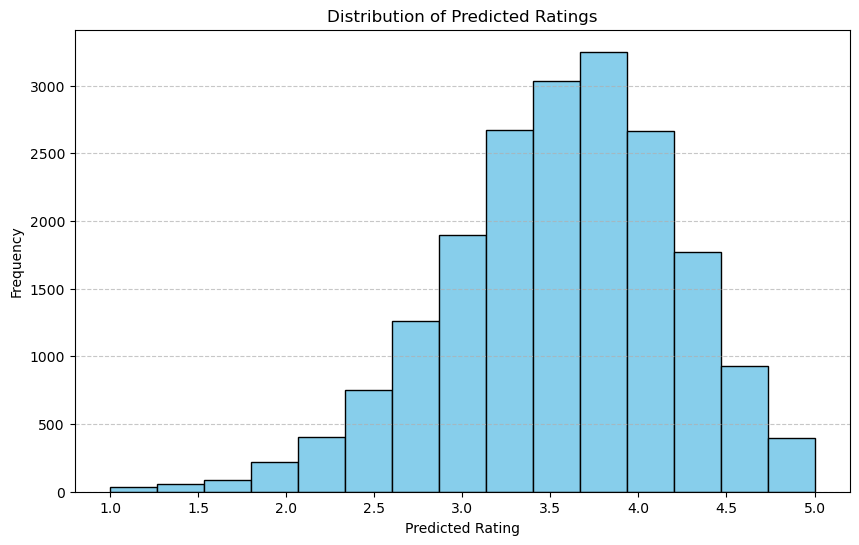

```python
# Create a histogram of the predicted ratings distribution
plt.figure(figsize=(10, 6))
plt.hist(merged_df['predicted'], bins=15, color='skyblue', edgecolor='black')
plt.title('Distribution of Predicted Ratings')
plt.xlabel('Predicted Rating')
plt.ylabel('Frequency')
plt.grid(axis='y', linestyle='--', alpha=0.7)
plt.show()
```

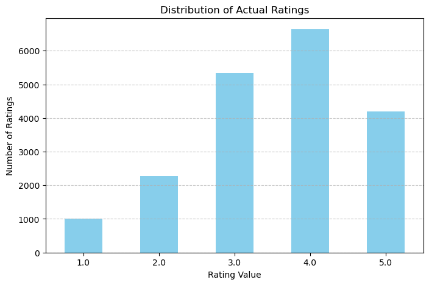

```python
# Count the occurrences of each rating
rating_counts = merged_df['actual'].value_counts().sort_index()

# Create a bar plot
plt.figure(figsize=(8, 5))
rating_counts.plot(kind='bar', color='skyblue')
plt.title('Distribution of Actual Ratings')
plt.xlabel('Rating Value')
plt.ylabel('Number of Ratings')
plt.xticks(rotation=0)
plt.grid(axis='y', linestyle='--', alpha=0.7)
plt.show()
```

4. Describe the distribution of actual to predicted and draw a conclusion about the quality of the recommender system.

**Predicted Ratings Distribution:**

**Actual Ratings Distribution:**

**Comparison and Conclusion:**

The model appears to be reasonably accurate in predicting ratings around the mean but may be underpredicting the number of extreme ratings. This could result from a model that overly regularizes or aims to avoid overfitting, thus gravitating predictions towards the mean. The fact that the predicted ratings are more normally distributed than the actual ratings suggests the model may not be capturing the full breadth of user preferences, particularly for items that users feel very strongly about (either positively or negatively). In summary, while the recommender system seems to have a good grasp on the average movie ratings, it might benefit from modifications that allow it to better capture the higher and lower extremes seen in user behavior. This could involve incorporating more user or item-specific information, tuning the algorithm's hyperparameters, or using a hybrid model that combines collaborative filtering with content-based methods.

# ✍️ Respond to the question in this markdown cell ✍️

5. Generate a plot of the error of predicted ratings.

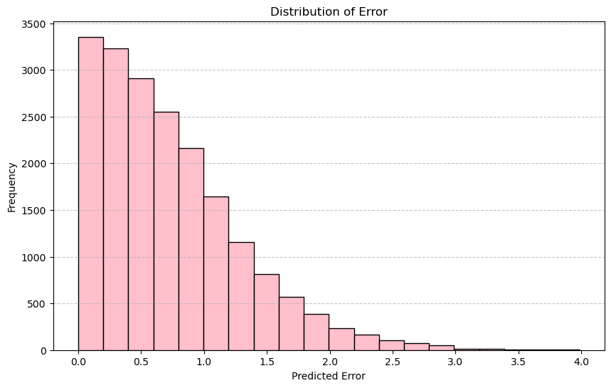

```python
# Create a histogram of the predicted ratings distribution
plt.figure(figsize=(10, 6))
plt.hist(merged_df['error'], bins=20, color='pink', edgecolor='black')
plt.title('Distribution of Error')
plt.xlabel('Predicted Error')
plt.ylabel('Frequency')
plt.grid(axis='y', linestyle='--', alpha=0.7)
plt.show()
```

a distribution of absolute errors cannot be normally distributed because absolute errors do not include negative values; they are always zero or positive. So we decided to create non-absolute errors to make a error distribution.

```python
merged_df
```

|  | uid | iid | actual | predicted | details | Iu | Ui | error | title |
| --- | --- | --- | --- | --- | --- | --- | --- | --- | --- |
| 0 | 267 | 164 | 3.0 | 3.772379 | {'was_impossible': False} | 86 | 90 | 0.772379 | Abyss, The (1989) |
| 1 | 75 | 685 | 4.0 | 3.063316 | {'was_impossible': False} | 38 | 95 | 0.936684 | Executive Decision (1996) |
| 2 | 545 | 1 | 5.0 | 4.064798 | {'was_impossible': False} | 114 | 286 | 0.935202 | Toy Story (1995) |
| 3 | 882 | 932 | 4.0 | 3.095704 | {'was_impossible': False} | 91 | 24 | 0.904296 | First Kid (1996) |
| 4 | 526 | 342 | 2.0 | 2.377049 | {'was_impossible': False} | 51 | 33 | 0.377049 | Man Who Knew Too Little, The (1997) |
| ... | ... | ... | ... | ... | ... | ... | ... | ... | ... |
| 19426 | 886 | 100 | 4.0 | 3.341044 | {'was_impossible': False} | 175 | 289 | 0.658956 | Fargo (1996) |
| 19427 | 804 | 91 | 4.0 | 3.489674 | {'was_impossible': False} | 258 | 88 | 0.510326 | Nightmare Before Christmas, The (1993) |
| 19428 | 606 | 148 | 3.0 | 3.727342 | {'was_impossible': False} | 168 | 69 | 0.727342 | Ghost and the Darkness, The (1996) |
| 19429 | 472 | 831 | 5.0 | 3.599724 | {'was_impossible': False} | 188 | 49 | 1.400276 | Escape from L.A. (1996) |
| 19430 | 536 | 480 | 5.0 | 4.567560 | {'was_impossible': False} | 118 | 101 | 0.432440 | North by Northwest (1959) |

19431 rows × 9 columns

```python
error = (merged_df['actual'] - merged_df['predicted'])
error
```

```
0       -0.772379
1        0.936684
2        0.935202
3        0.904296
4       -0.377049
           ...
19426    0.658956
19427    0.510326
19428   -0.727342
19429    1.400276
19430    0.432440
Length: 19431, dtype: float64
```

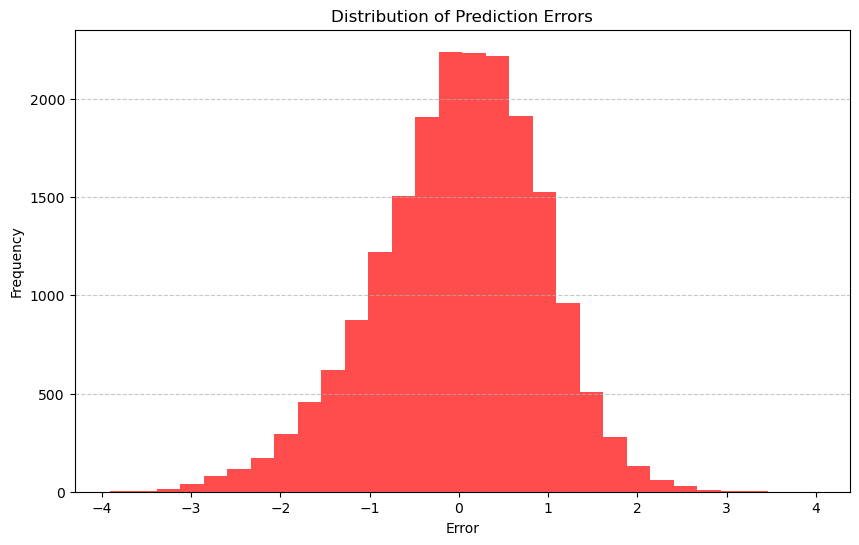

```python
plt.figure(figsize=(10, 6))
plt.hist(error, bins=30, alpha=0.7, color='red')
plt.title('Distribution of Prediction Errors')
plt.xlabel('Error')
plt.ylabel('Frequency')
plt.grid(axis='y', linestyle='--', alpha=0.7)
plt.show()
```

6. Describe the nature of the models errors.
- Did the model do well with low ratings or high ratings?
- Were the errors normally distributed?

**Nature of the Model's Errors:**

The distribution is centered around zero, suggesting that the recommender system does not systematically overpredict or underpredict ratings. The histogram displays a near-normal distribution of errors, which is a good indication of random errors without bias.

**Model Performance on Low vs. High Ratings:**

To determine how the model performed on low versus high ratings, we would typically analyze the error in relation to the actual ratings. However, from this histogram alone, we can't discern the model's performance on low versus high ratings without additional information. A scatter plot of actual ratings vs. errors could provide insights into whether the model has a tendency to err more in one direction for low or high ratings.

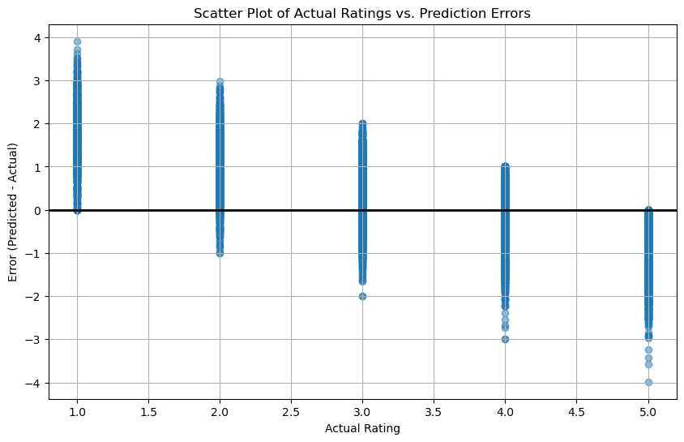

```python
import pandas as pd
import matplotlib.pyplot as plt

# Assuming 'df' is your DataFrame with 'actual' and 'predicted' columns
merged_df['non-absolute_error'] = merged_df['predicted'] - merged_df['actual']

# Now create the scatter plot
plt.figure(figsize=(10, 6))
plt.scatter(merged_df['actual'], merged_df['non-absolute_error'], alpha=0.5)
plt.title('Scatter Plot of Actual Ratings vs. Prediction Errors')
plt.xlabel('Actual Rating')
plt.ylabel('Error (Predicted - Actual)')
plt.axhline(0, color='black', lw=2)  # This adds a line at error=0
plt.grid(True)
plt.show()
```

**Outliers:** The plot shows several points far from the zero-error line, indicating some predictions with large errors. This could mean that certain user-item interactions are not well understood by the model, or there could be outliers in the data.

**Conclusions:**

The recommender system appears to handle mid-range ratings more consistently than extreme ratings. The model may benefit from further refinement to better understand the factors that lead to high satisfaction (rating of 5) or dissatisfaction (rating of 1), as these are areas with larger errors.

# ✍️ Respond to the question in this markdown cell ✍️

7. Select user `665` and conduct an analysis the predicted ratings for this user.
- Which movie predictions were best?
- Which movie predictions were worst?
- What, additional data, could possible improve predictions?

```python
# Filter for user 665
user_665_data = merged_df[merged_df['uid'] == 665]
user_665_data
```

|  | uid | iid | actual | predicted | details | Iu | Ui | error | title | non-absolute_error |
| --- | --- | --- | --- | --- | --- | --- | --- | --- | --- | --- |
| 448 | 665 | 369 | 4.0 | 2.764186 | {'was_impossible': False} | 106 | 26 | 1.235814 | Black Sheep (1996) | -1.235814 |
| 450 | 665 | 423 | 4.0 | 3.663080 | {'was_impossible': False} | 106 | 171 | 0.336920 | E.T. the Extra-Terrestrial (1982) | -0.336920 |
| 817 | 665 | 762 | 4.0 | 3.314232 | {'was_impossible': False} | 106 | 75 | 0.685768 | Beautiful Girls (1996) | -0.685768 |
| 851 | 665 | 313 | 4.0 | 3.958179 | {'was_impossible': False} | 106 | 209 | 0.041821 | Titanic (1997) | -0.041821 |
| 1038 | 665 | 684 | 3.0 | 3.561388 | {'was_impossible': False} | 106 | 108 | 0.561388 | In the Line of Fire (1993) | 0.561388 |
| 2456 | 665 | 293 | 4.0 | 3.474427 | {'was_impossible': False} | 106 | 97 | 0.525573 | Donnie Brasco (1997) | -0.525573 |
| 2726 | 665 | 255 | 4.0 | 3.123846 | {'was_impossible': False} | 106 | 111 | 0.876154 | My Best Friend's Wedding (1997) | -0.876154 |
| 3072 | 665 | 92 | 4.0 | 3.688176 | {'was_impossible': False} | 106 | 57 | 0.311824 | True Romance (1993) | -0.311824 |
| 4069 | 665 | 427 | 5.0 | 4.114702 | {'was_impossible': False} | 106 | 138 | 0.885298 | To Kill a Mockingbird (1962) | -0.885298 |
| 4356 | 665 | 294 | 2.0 | 2.779387 | {'was_impossible': False} | 106 | 297 | 0.779387 | Liar Liar (1997) | 0.779387 |
| 4598 | 665 | 456 | 4.0 | 2.538736 | {'was_impossible': False} | 106 | 33 | 1.461264 | Beverly Hills Ninja (1997) | -1.461264 |
| 5850 | 665 | 88 | 3.0 | 2.999407 | {'was_impossible': False} | 106 | 127 | 0.000593 | Sleepless in Seattle (1993) | -0.000593 |
| 6030 | 665 | 194 | 3.0 | 3.852171 | {'was_impossible': False} | 106 | 139 | 0.852171 | Sting, The (1973) | 0.852171 |
| 6203 | 665 | 473 | 4.0 | 3.031786 | {'was_impossible': False} | 106 | 75 | 0.968214 | James and the Giant Peach (1996) | -0.968214 |
| 6796 | 665 | 926 | 3.0 | 2.752449 | {'was_impossible': False} | 106 | 60 | 0.247551 | Down Periscope (1996) | -0.247551 |
| 7974 | 665 | 69 | 5.0 | 3.549044 | {'was_impossible': False} | 106 | 195 | 1.450956 | Forrest Gump (1994) | -1.450956 |
| 8908 | 665 | 96 | 3.0 | 3.538963 | {'was_impossible': False} | 106 | 174 | 0.538963 | Terminator 2: Judgment Day (1991) | 0.538963 |
| 9574 | 665 | 202 | 3.0 | 3.318056 | {'was_impossible': False} | 106 | 164 | 0.318056 | Groundhog Day (1993) | 0.318056 |
| 9798 | 665 | 111 | 4.0 | 3.302674 | {'was_impossible': False} | 106 | 184 | 0.697326 | Truth About Cats & Dogs, The (1996) | -0.697326 |
| 10866 | 665 | 748 | 4.0 | 2.973438 | {'was_impossible': False} | 106 | 184 | 1.026562 | Saint, The (1997) | -1.026562 |
| 11992 | 665 | 121 | 2.0 | 3.185961 | {'was_impossible': False} | 106 | 274 | 1.185961 | Independence Day (ID4) (1996) | 1.185961 |
| 12479 | 665 | 71 | 4.0 | 3.587238 | {'was_impossible': False} | 106 | 125 | 0.412762 | Lion King, The (1994) | -0.412762 |
| 12814 | 665 | 216 | 4.0 | 3.706096 | {'was_impossible': False} | 106 | 166 | 0.293904 | When Harry Met Sally... (1989) | -0.293904 |
| 14485 | 665 | 1009 | 4.0 | 3.325962 | {'was_impossible': False} | 106 | 42 | 0.674038 | Stealing Beauty (1996) | -0.674038 |
| 14491 | 665 | 248 | 4.0 | 3.348654 | {'was_impossible': False} | 106 | 102 | 0.651346 | Grosse Pointe Blank (1997) | -0.651346 |
| 14729 | 665 | 181 | 4.0 | 3.430470 | {'was_impossible': False} | 106 | 323 | 0.569530 | Return of the Jedi (1983) | -0.569530 |
| 14766 | 665 | 393 | 3.0 | 3.256925 | {'was_impossible': False} | 106 | 121 | 0.256925 | Mrs. Doubtfire (1993) | 0.256925 |
| 15478 | 665 | 265 | 3.0 | 3.521311 | {'was_impossible': False} | 106 | 132 | 0.521311 | Hunt for Red October, The (1990) | 0.521311 |
| 15628 | 665 | 411 | 4.0 | 3.153803 | {'was_impossible': False} | 106 | 96 | 0.846197 | Nutty Professor, The (1996) | -0.846197 |
| 15669 | 665 | 147 | 4.0 | 3.366392 | {'was_impossible': False} | 106 | 108 | 0.633608 | Long Kiss Goodnight, The (1996) | -0.633608 |
| 15751 | 665 | 151 | 3.0 | 3.278805 | {'was_impossible': False} | 106 | 189 | 0.278805 | Willy Wonka and the Chocolate Factory (1971) | 0.278805 |
| 15913 | 665 | 527 | 3.0 | 3.790005 | {'was_impossible': False} | 106 | 110 | 0.790005 | Gandhi (1982) | 0.790005 |
| 17077 | 665 | 1040 | 4.0 | 2.758958 | {'was_impossible': False} | 106 | 13 | 1.241042 | Two if by Sea (1996) | -1.241042 |
| 17492 | 665 | 24 | 3.0 | 3.130626 | {'was_impossible': False} | 106 | 107 | 0.130626 | Rumble in the Bronx (1995) | 0.130626 |
| 17682 | 665 | 1047 | 1.0 | 2.876506 | {'was_impossible': False} | 106 | 80 | 1.876506 | Multiplicity (1996) | 1.876506 |
| 19051 | 665 | 9 | 4.0 | 3.881908 | {'was_impossible': False} | 106 | 181 | 0.118092 | Dead Man Walking (1995) | -0.118092 |

```python
# Sort by the absolute error column in ascending order to find the best predictions
best_predictions = user_665_data.loc[user_665_data['error'].sort_values().index]

best_predictions
```

|  | uid | iid | actual | predicted | details | Iu | Ui | error | title | non-absolute_error |
| --- | --- | --- | --- | --- | --- | --- | --- | --- | --- | --- |
| 5850 | 665 | 88 | 3.0 | 2.999407 | {'was_impossible': False} | 106 | 127 | 0.000593 | Sleepless in Seattle (1993) | -0.000593 |
| 851 | 665 | 313 | 4.0 | 3.958179 | {'was_impossible': False} | 106 | 209 | 0.041821 | Titanic (1997) | -0.041821 |
| 19051 | 665 | 9 | 4.0 | 3.881908 | {'was_impossible': False} | 106 | 181 | 0.118092 | Dead Man Walking (1995) | -0.118092 |
| 17492 | 665 | 24 | 3.0 | 3.130626 | {'was_impossible': False} | 106 | 107 | 0.130626 | Rumble in the Bronx (1995) | 0.130626 |
| 6796 | 665 | 926 | 3.0 | 2.752449 | {'was_impossible': False} | 106 | 60 | 0.247551 | Down Periscope (1996) | -0.247551 |
| 14766 | 665 | 393 | 3.0 | 3.256925 | {'was_impossible': False} | 106 | 121 | 0.256925 | Mrs. Doubtfire (1993) | 0.256925 |
| 15751 | 665 | 151 | 3.0 | 3.278805 | {'was_impossible': False} | 106 | 189 | 0.278805 | Willy Wonka and the Chocolate Factory (1971) | 0.278805 |
| 12814 | 665 | 216 | 4.0 | 3.706096 | {'was_impossible': False} | 106 | 166 | 0.293904 | When Harry Met Sally... (1989) | -0.293904 |
| 3072 | 665 | 92 | 4.0 | 3.688176 | {'was_impossible': False} | 106 | 57 | 0.311824 | True Romance (1993) | -0.311824 |
| 9574 | 665 | 202 | 3.0 | 3.318056 | {'was_impossible': False} | 106 | 164 | 0.318056 | Groundhog Day (1993) | 0.318056 |
| 450 | 665 | 423 | 4.0 | 3.663080 | {'was_impossible': False} | 106 | 171 | 0.336920 | E.T. the Extra-Terrestrial (1982) | -0.336920 |
| 12479 | 665 | 71 | 4.0 | 3.587238 | {'was_impossible': False} | 106 | 125 | 0.412762 | Lion King, The (1994) | -0.412762 |
| 15478 | 665 | 265 | 3.0 | 3.521311 | {'was_impossible': False} | 106 | 132 | 0.521311 | Hunt for Red October, The (1990) | 0.521311 |
| 2456 | 665 | 293 | 4.0 | 3.474427 | {'was_impossible': False} | 106 | 97 | 0.525573 | Donnie Brasco (1997) | -0.525573 |
| 8908 | 665 | 96 | 3.0 | 3.538963 | {'was_impossible': False} | 106 | 174 | 0.538963 | Terminator 2: Judgment Day (1991) | 0.538963 |
| 1038 | 665 | 684 | 3.0 | 3.561388 | {'was_impossible': False} | 106 | 108 | 0.561388 | In the Line of Fire (1993) | 0.561388 |
| 14729 | 665 | 181 | 4.0 | 3.430470 | {'was_impossible': False} | 106 | 323 | 0.569530 | Return of the Jedi (1983) | -0.569530 |
| 15669 | 665 | 147 | 4.0 | 3.366392 | {'was_impossible': False} | 106 | 108 | 0.633608 | Long Kiss Goodnight, The (1996) | -0.633608 |
| 14491 | 665 | 248 | 4.0 | 3.348654 | {'was_impossible': False} | 106 | 102 | 0.651346 | Grosse Pointe Blank (1997) | -0.651346 |
| 14485 | 665 | 1009 | 4.0 | 3.325962 | {'was_impossible': False} | 106 | 42 | 0.674038 | Stealing Beauty (1996) | -0.674038 |
| 817 | 665 | 762 | 4.0 | 3.314232 | {'was_impossible': False} | 106 | 75 | 0.685768 | Beautiful Girls (1996) | -0.685768 |
| 9798 | 665 | 111 | 4.0 | 3.302674 | {'was_impossible': False} | 106 | 184 | 0.697326 | Truth About Cats & Dogs, The (1996) | -0.697326 |
| 4356 | 665 | 294 | 2.0 | 2.779387 | {'was_impossible': False} | 106 | 297 | 0.779387 | Liar Liar (1997) | 0.779387 |
| 15913 | 665 | 527 | 3.0 | 3.790005 | {'was_impossible': False} | 106 | 110 | 0.790005 | Gandhi (1982) | 0.790005 |
| 15628 | 665 | 411 | 4.0 | 3.153803 | {'was_impossible': False} | 106 | 96 | 0.846197 | Nutty Professor, The (1996) | -0.846197 |
| 6030 | 665 | 194 | 3.0 | 3.852171 | {'was_impossible': False} | 106 | 139 | 0.852171 | Sting, The (1973) | 0.852171 |
| 2726 | 665 | 255 | 4.0 | 3.123846 | {'was_impossible': False} | 106 | 111 | 0.876154 | My Best Friend's Wedding (1997) | -0.876154 |
| 4069 | 665 | 427 | 5.0 | 4.114702 | {'was_impossible': False} | 106 | 138 | 0.885298 | To Kill a Mockingbird (1962) | -0.885298 |
| 6203 | 665 | 473 | 4.0 | 3.031786 | {'was_impossible': False} | 106 | 75 | 0.968214 | James and the Giant Peach (1996) | -0.968214 |
| 10866 | 665 | 748 | 4.0 | 2.973438 | {'was_impossible': False} | 106 | 184 | 1.026562 | Saint, The (1997) | -1.026562 |
| 11992 | 665 | 121 | 2.0 | 3.185961 | {'was_impossible': False} | 106 | 274 | 1.185961 | Independence Day (ID4) (1996) | 1.185961 |
| 448 | 665 | 369 | 4.0 | 2.764186 | {'was_impossible': False} | 106 | 26 | 1.235814 | Black Sheep (1996) | -1.235814 |
| 17077 | 665 | 1040 | 4.0 | 2.758958 | {'was_impossible': False} | 106 | 13 | 1.241042 | Two if by Sea (1996) | -1.241042 |
| 7974 | 665 | 69 | 5.0 | 3.549044 | {'was_impossible': False} | 106 | 195 | 1.450956 | Forrest Gump (1994) | -1.450956 |
| 4598 | 665 | 456 | 4.0 | 2.538736 | {'was_impossible': False} | 106 | 33 | 1.461264 | Beverly Hills Ninja (1997) | -1.461264 |
| 17682 | 665 | 1047 | 1.0 | 2.876506 | {'was_impossible': False} | 106 | 80 | 1.876506 | Multiplicity (1996) | 1.876506 |

```python
# Sort by the absolute error column in descending order to find the worst predictions
worst_predictions = user_665_data.loc[user_665_data['error'].abs().sort_values(ascending=False).index]

worst_predictions
```

|  | uid | iid | actual | predicted | details | Iu | Ui | error | title | non-absolute_error |
| --- | --- | --- | --- | --- | --- | --- | --- | --- | --- | --- |
| 17682 | 665 | 1047 | 1.0 | 2.876506 | {'was_impossible': False} | 106 | 80 | 1.876506 | Multiplicity (1996) | 1.876506 |
| 4598 | 665 | 456 | 4.0 | 2.538736 | {'was_impossible': False} | 106 | 33 | 1.461264 | Beverly Hills Ninja (1997) | -1.461264 |
| 7974 | 665 | 69 | 5.0 | 3.549044 | {'was_impossible': False} | 106 | 195 | 1.450956 | Forrest Gump (1994) | -1.450956 |
| 17077 | 665 | 1040 | 4.0 | 2.758958 | {'was_impossible': False} | 106 | 13 | 1.241042 | Two if by Sea (1996) | -1.241042 |
| 448 | 665 | 369 | 4.0 | 2.764186 | {'was_impossible': False} | 106 | 26 | 1.235814 | Black Sheep (1996) | -1.235814 |
| 11992 | 665 | 121 | 2.0 | 3.185961 | {'was_impossible': False} | 106 | 274 | 1.185961 | Independence Day (ID4) (1996) | 1.185961 |
| 10866 | 665 | 748 | 4.0 | 2.973438 | {'was_impossible': False} | 106 | 184 | 1.026562 | Saint, The (1997) | -1.026562 |
| 6203 | 665 | 473 | 4.0 | 3.031786 | {'was_impossible': False} | 106 | 75 | 0.968214 | James and the Giant Peach (1996) | -0.968214 |
| 4069 | 665 | 427 | 5.0 | 4.114702 | {'was_impossible': False} | 106 | 138 | 0.885298 | To Kill a Mockingbird (1962) | -0.885298 |
| 2726 | 665 | 255 | 4.0 | 3.123846 | {'was_impossible': False} | 106 | 111 | 0.876154 | My Best Friend's Wedding (1997) | -0.876154 |
| 6030 | 665 | 194 | 3.0 | 3.852171 | {'was_impossible': False} | 106 | 139 | 0.852171 | Sting, The (1973) | 0.852171 |
| 15628 | 665 | 411 | 4.0 | 3.153803 | {'was_impossible': False} | 106 | 96 | 0.846197 | Nutty Professor, The (1996) | -0.846197 |
| 15913 | 665 | 527 | 3.0 | 3.790005 | {'was_impossible': False} | 106 | 110 | 0.790005 | Gandhi (1982) | 0.790005 |
| 4356 | 665 | 294 | 2.0 | 2.779387 | {'was_impossible': False} | 106 | 297 | 0.779387 | Liar Liar (1997) | 0.779387 |
| 9798 | 665 | 111 | 4.0 | 3.302674 | {'was_impossible': False} | 106 | 184 | 0.697326 | Truth About Cats & Dogs, The (1996) | -0.697326 |
| 817 | 665 | 762 | 4.0 | 3.314232 | {'was_impossible': False} | 106 | 75 | 0.685768 | Beautiful Girls (1996) | -0.685768 |
| 14485 | 665 | 1009 | 4.0 | 3.325962 | {'was_impossible': False} | 106 | 42 | 0.674038 | Stealing Beauty (1996) | -0.674038 |
| 14491 | 665 | 248 | 4.0 | 3.348654 | {'was_impossible': False} | 106 | 102 | 0.651346 | Grosse Pointe Blank (1997) | -0.651346 |
| 15669 | 665 | 147 | 4.0 | 3.366392 | {'was_impossible': False} | 106 | 108 | 0.633608 | Long Kiss Goodnight, The (1996) | -0.633608 |
| 14729 | 665 | 181 | 4.0 | 3.430470 | {'was_impossible': False} | 106 | 323 | 0.569530 | Return of the Jedi (1983) | -0.569530 |
| 1038 | 665 | 684 | 3.0 | 3.561388 | {'was_impossible': False} | 106 | 108 | 0.561388 | In the Line of Fire (1993) | 0.561388 |
| 8908 | 665 | 96 | 3.0 | 3.538963 | {'was_impossible': False} | 106 | 174 | 0.538963 | Terminator 2: Judgment Day (1991) | 0.538963 |
| 2456 | 665 | 293 | 4.0 | 3.474427 | {'was_impossible': False} | 106 | 97 | 0.525573 | Donnie Brasco (1997) | -0.525573 |
| 15478 | 665 | 265 | 3.0 | 3.521311 | {'was_impossible': False} | 106 | 132 | 0.521311 | Hunt for Red October, The (1990) | 0.521311 |
| 12479 | 665 | 71 | 4.0 | 3.587238 | {'was_impossible': False} | 106 | 125 | 0.412762 | Lion King, The (1994) | -0.412762 |
| 450 | 665 | 423 | 4.0 | 3.663080 | {'was_impossible': False} | 106 | 171 | 0.336920 | E.T. the Extra-Terrestrial (1982) | -0.336920 |
| 9574 | 665 | 202 | 3.0 | 3.318056 | {'was_impossible': False} | 106 | 164 | 0.318056 | Groundhog Day (1993) | 0.318056 |
| 3072 | 665 | 92 | 4.0 | 3.688176 | {'was_impossible': False} | 106 | 57 | 0.311824 | True Romance (1993) | -0.311824 |
| 12814 | 665 | 216 | 4.0 | 3.706096 | {'was_impossible': False} | 106 | 166 | 0.293904 | When Harry Met Sally... (1989) | -0.293904 |
| 15751 | 665 | 151 | 3.0 | 3.278805 | {'was_impossible': False} | 106 | 189 | 0.278805 | Willy Wonka and the Chocolate Factory (1971) | 0.278805 |
| 14766 | 665 | 393 | 3.0 | 3.256925 | {'was_impossible': False} | 106 | 121 | 0.256925 | Mrs. Doubtfire (1993) | 0.256925 |
| 6796 | 665 | 926 | 3.0 | 2.752449 | {'was_impossible': False} | 106 | 60 | 0.247551 | Down Periscope (1996) | -0.247551 |
| 17492 | 665 | 24 | 3.0 | 3.130626 | {'was_impossible': False} | 106 | 107 | 0.130626 | Rumble in the Bronx (1995) | 0.130626 |
| 19051 | 665 | 9 | 4.0 | 3.881908 | {'was_impossible': False} | 106 | 181 | 0.118092 | Dead Man Walking (1995) | -0.118092 |
| 851 | 665 | 313 | 4.0 | 3.958179 | {'was_impossible': False} | 106 | 209 | 0.041821 | Titanic (1997) | -0.041821 |
| 5850 | 665 | 88 | 3.0 | 2.999407 | {'was_impossible': False} | 106 | 127 | 0.000593 | Sleepless in Seattle (1993) | -0.000593 |

```python
# Display the best movie predictions for user 665
print("Best movie predictions for user 665:")
print(best_predictions[['title', 'actual', 'predicted', 'error']].head())
```

```
Best movie predictions for user 665:
                             title  actual  predicted     error
5850   Sleepless in Seattle (1993)     3.0   2.999407  0.000593
851                 Titanic (1997)     4.0   3.958179  0.041821
19051      Dead Man Walking (1995)     4.0   3.881908  0.118092
17492   Rumble in the Bronx (1995)     3.0   3.130626  0.130626
6796         Down Periscope (1996)     3.0   2.752449  0.247551
```

The movie with the best prediction was **"Sleepless in Seattle (1993)"** with an almost negligible error

```python
# Display the worst movie predictions for user 665
print("\nWorst movie predictions for user 665:")
print(worst_predictions[['title', 'actual', 'predicted', 'error']].head())
```

```
Worst movie predictions for user 665:
                            title  actual  predicted     error
17682         Multiplicity (1996)     1.0   2.876506  1.876506
4598   Beverly Hills Ninja (1997)     4.0   2.538736  1.461264
7974          Forrest Gump (1994)     5.0   3.549044  1.450956
17077        Two if by Sea (1996)     4.0   2.758958  1.241042
448            Black Sheep (1996)     4.0   2.764186  1.235814
```

The movie **"Multiplicity (1996)"** had the largest error, indicating that the model's prediction was quite far from the actual user rating.

### What, additional data, could possible improve predictions?

- **User Profile Data:** Information about the user's demographics, such as age, gender, location, and perhaps occupation, could help tailor predictions to match the user's preferences more closely.
- **Content Features:** Detailed metadata about the movies, like genres, directors, cast members, movie release dates, and plot summaries, could provide more signals to improve the content-based aspect of the predictions.
- **Temporal Data:** Users' tastes can change over time, and they might be influenced by temporal dynamics such as seasonal trends or the release of sequels or related movies.
- **Contextual Information:** The context in which ratings are given can be important. For example, whether the movie was watched in a theater or at home, alone or with others, can affect a user's rating.

# ✍️ Respond to the question in this markdown cell ✍️